# R Notebook

# Preface

I’m copy-pasting much from the previous report to save time.

> I will put new information/changes in block quotes like this.

# Intro

Hey Mayra,

Below are (at least several of) the plots you asked for. Let me know if I missed any.

For each type of plot, I included several replicates for varying number of genes to help you pick a number to display that you like.

# Heatmap of DE between each pair of treatment groups at each time

## Ordered by $p$-value

# Data visualization

First, we plot a hierarchical clustering of the data according to the raw estimated number of counts. The plot shows that batches a, b/c, and d have huge differences between them, which cause the batch effect to be much more prevalent than either the treatment or time effect. In particular, batch a seems much further than the others, while batch d seems fairly close to b/c. Batch d contains only samples after 48 hours, so differences between it and b/c are unsurprising.

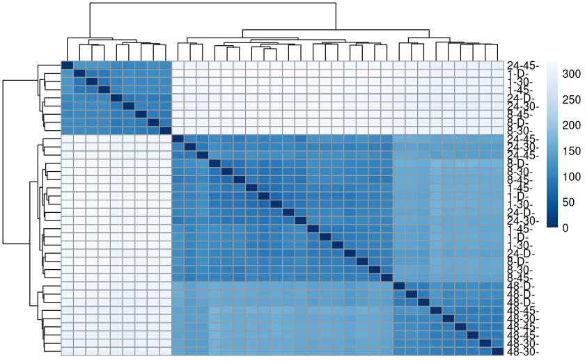

A PCA plot supports this notion. This one seems to suggest that the vast majority of variance in the data can be attributed to variation between batch a, and the others. After that, the next largest contributor to variance seems to be differentiating between groups b/c and d, and, finally, between b and c.

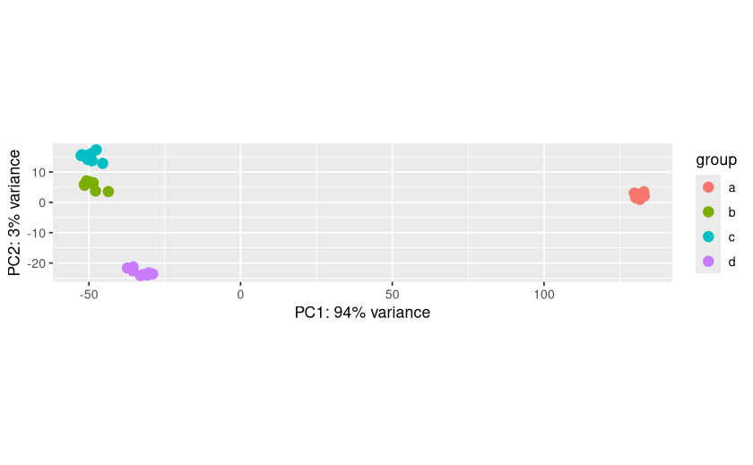

After normalizing, we model our data as
$$\log_2y_{gitjk} = \mu_g + {\rm Treatment}_{gi} + {\rm Time}_{gt} +
{\rm TreatmentTime}_{git} + {\rm BatchA}_{gj} + \varepsilon_{gitjk},$$
a linear model with an interaction between time and treatment, which includes a batch effect for batch A to account for varying levels of gene $g$ in DMSO after 1 hour in the batch A group compared to the rest. The null model is set as
$$\log_2y_{gitjk} = \mu_g + {\rm Time}_{gt} + {\rm BatchA}_{gj} +
\varepsilon_{gitjk},$$
which still contains the batch adjustment, but now asserts that there is no treatment effect on the log-counts.

For each gene, we conduct a LRT to compare the full model to the reduced, null model, and, from that obtain a $p$-value. Those $p$-values are then adjusted using the Benjamini-Hochberg correction, to obtain an estimated False Discovery Rate. False Discovery Rate cutoff is set at 0.05, and a total of 4181 genes are found to have a treatment effect.

We also extract from that model the MLE of the $\log_2$-fold change between DMSO and IC75 Atovaquone, each at 48 hours, to model the effect size of the treatment. The 10 genes with the lowest FDR are reported here.

|  | log2FoldChange | pvalue | padj |
| --- | --- | --- | --- |
| LDHA | -1.09 | 1.05e-134 | 1.67e-130 |
| KIF20A | -2.38 | 7.93e-85 | 6.28e-81 |
| DLGAP5 | -1.93 | 9.28e-83 | 4.9e-79 |
| HMMR | -2.23 | 3.79e-78 | 1.5e-74 |
| CAPRIN1 | -0.572 | 4.5e-75 | 1.43e-71 |
| IFRD1 | 1.57 | 1.34e-74 | 3.54e-71 |
| CCNB1 | -1.68 | 2.35e-69 | 5.33e-66 |
| AURKA | -2 | 5.61e-69 | 1.11e-65 |
| CEBPG | 1.25 | 2.19e-68 | 3.86e-65 |
| BUB1 | -1.54 | 9.39e-68 | 1.49e-64 |

To further investigate these genes, a heatmap showing the residuals under the null model that the values are dependent only on time is displayed. Each row is a gene (marked on the left, along with the estimated FDR), and each column is a sample. Higher residuals (more red) imply that the genes in that sample are more highly expressed than on average across samples.

Looking at the one-hour columns, we see that there is often little variation between the three treatments. However, DDIT3, in the presence of IC75 atovaquone, does seem to be elevated compared to DMSO after only one hour.

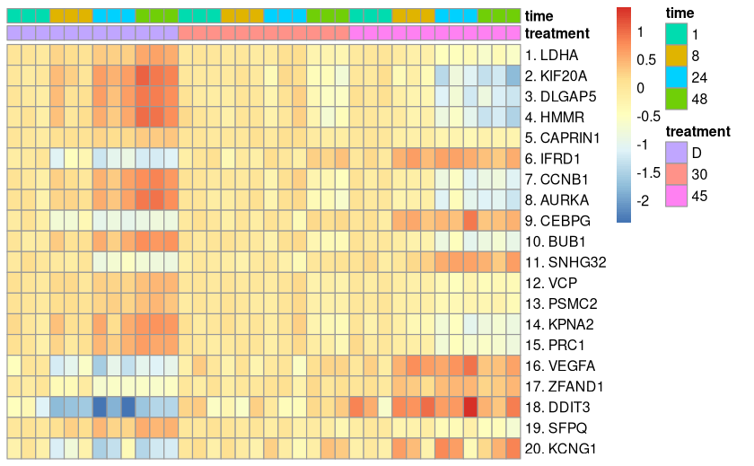

## Visualization of estimates of log2 fold-change

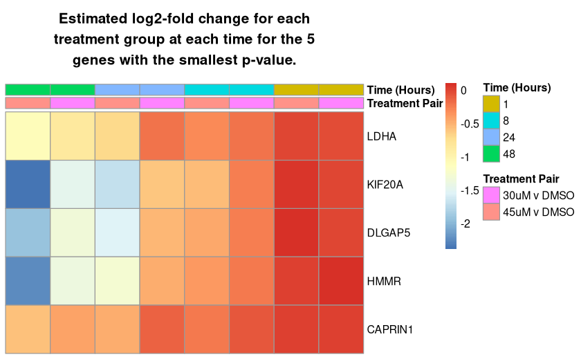

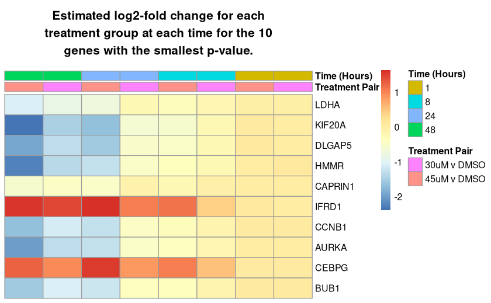

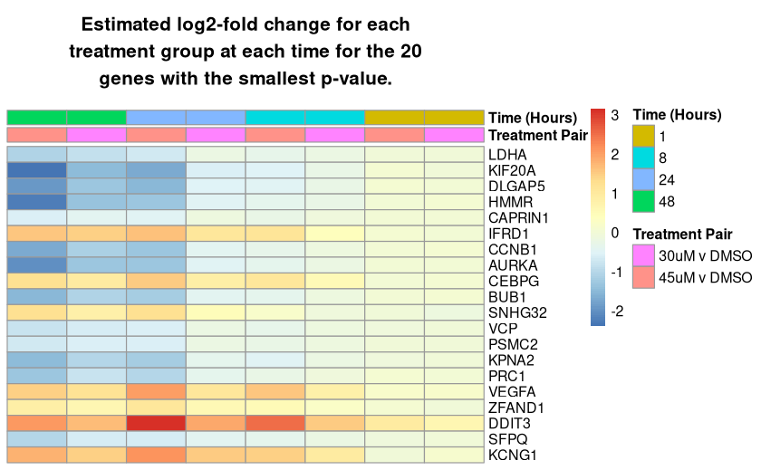

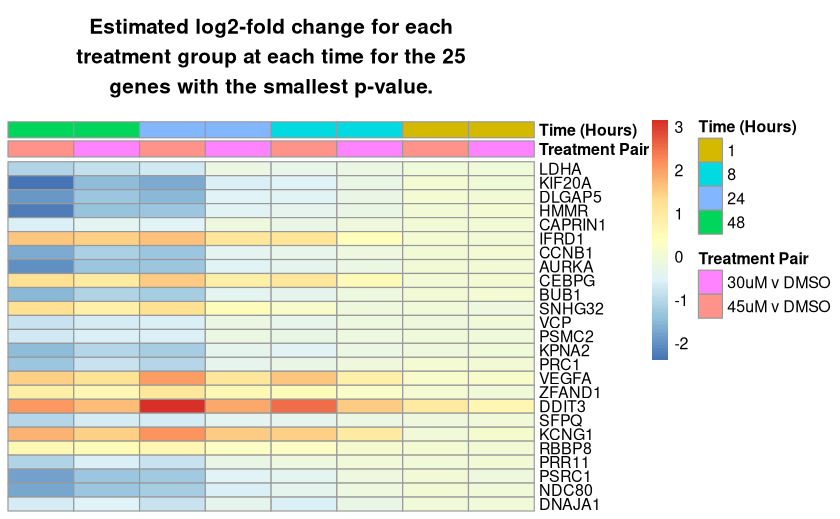

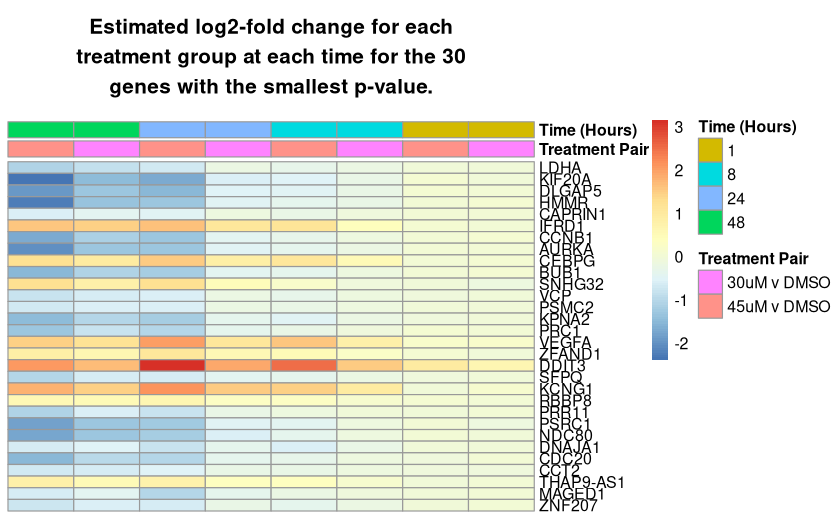

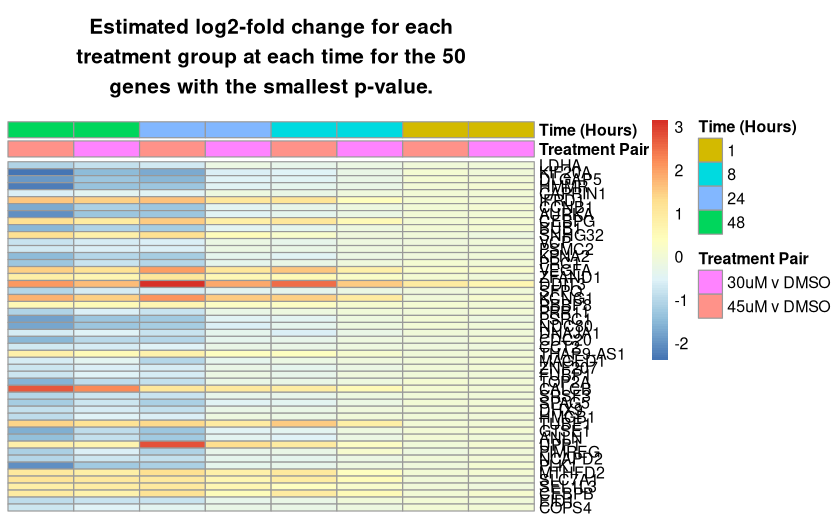

## Ordered by estimated effect size, restricted to FDR-controlled $p$-value < 0.05

> Now I show essentially the same images, but now we sort them by estimated effect size at 48 hours between 45$\mu$M and DMSO. For brevity, I include only one image for each, rather than for a range of #genes, but can trivially include more, if desired.

### Ordered by decreasing log fold-change (i.e. up-regulated)

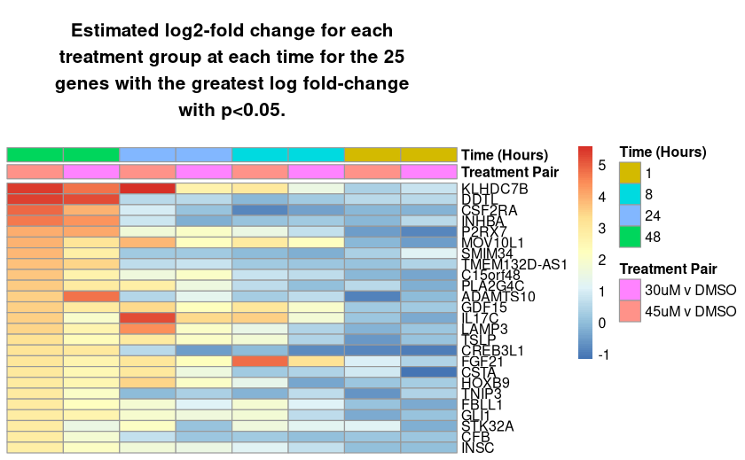

### Ordered by increasing log fold-change (i.e. down-regulated)

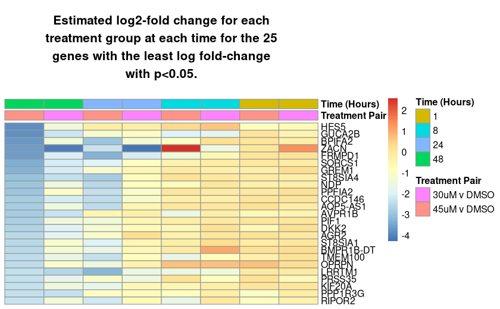

### Ordered by decreasing abs(log fold-change) (i.e. effect far from zero)

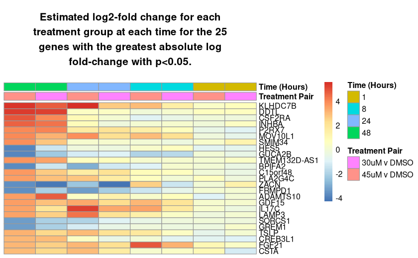

# Barplot of DE between each pair of treatment groups at each time

## Ordered by FDR-adjusted $p$

This contains pretty much the same information as above, but in a barplot. It may be slightly easier to glean info from this, but fewer genes will fit while still looking nice.

> I also made the same changes here that I did above.

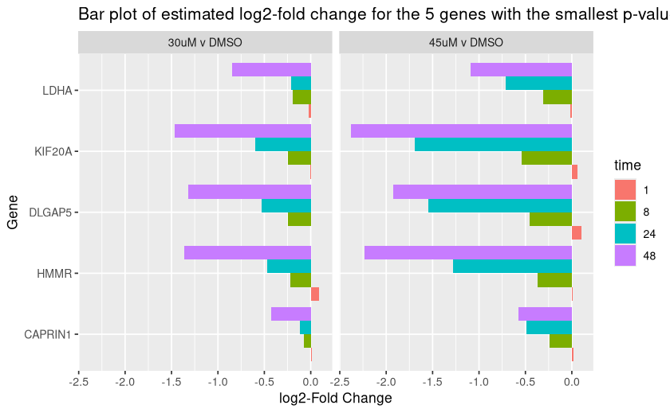

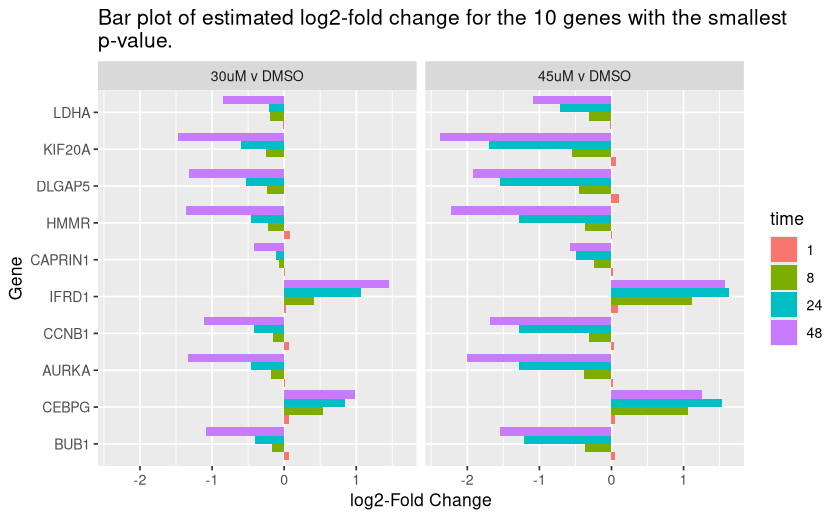

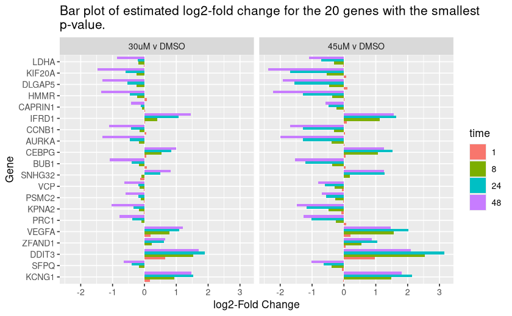

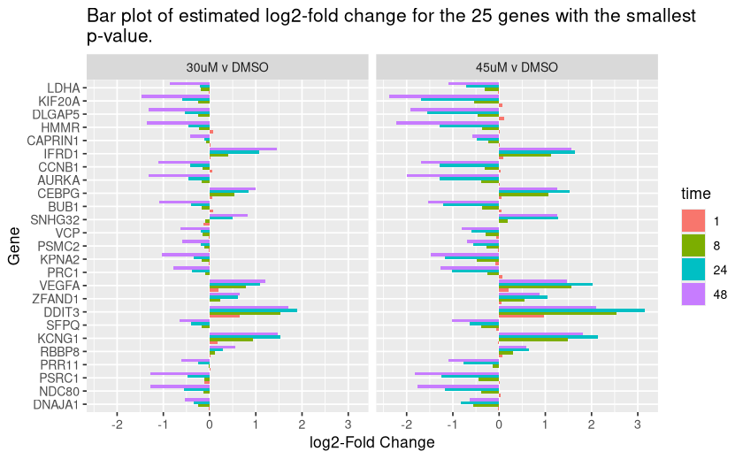

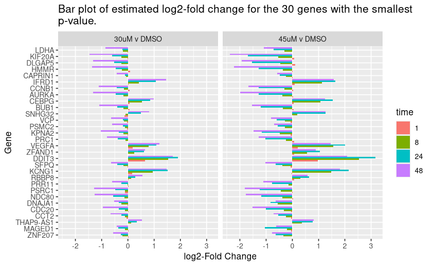

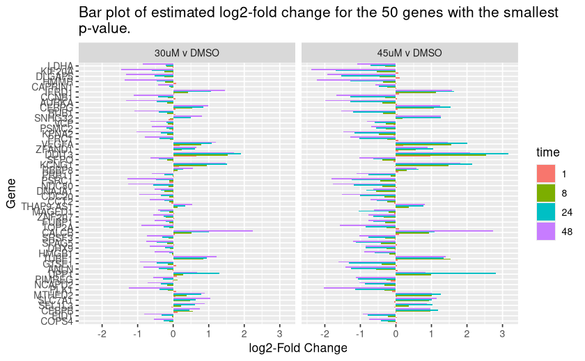

## Ordered by estimated effect size, restricted to FDR-controlled $p$-value < 0.05

### Ordered by decreasing log fold-change (i.e. up-regulated)

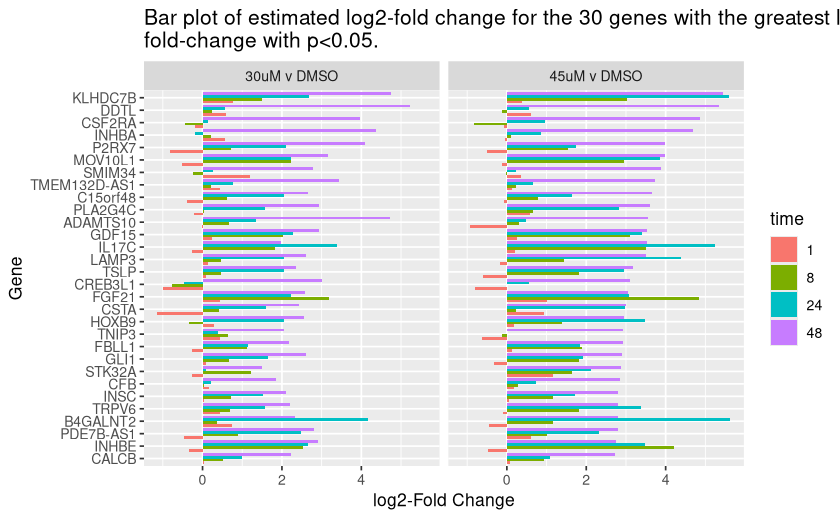

### Ordered by increasing log fold-change (i.e. down-regulated)

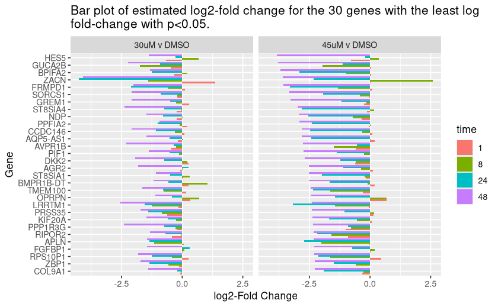

### Ordered by decreasing absolute log fold-change (i.e. effect far from zero)

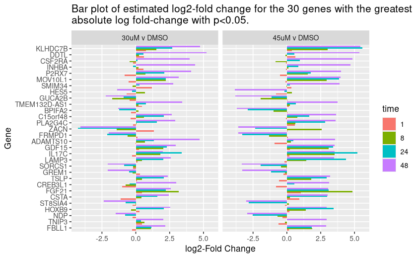